# Bike Sharing Demand (kaggle)-Forecast use of a city bikeshare system

## Argyrios Georgiadis

### January 2022

# Introduction

The dataset has been taken from https://www.kaggle.com/c/bike-sharing-demand/data

and included the following columns:  
**datetime** - hourly date + timestamp  
**season** - 1 = spring, 2 = summer, 3 = fall, 4 = winter  
**holiday** - whether the day is considered a holiday  
**workingday** - whether the day is neither a weekend nor holiday  
**weather** - 1: Clear, Few clouds, Partly cloudy, Partly cloudy 2: Mist + Cloudy, Mist + Broken clouds, Mist + Few clouds, Mist 3: Light Snow, Light Rain + Thunderstorm + Scattered clouds, Light Rain + Scattered clouds 4: Heavy Rain + Ice Pallets + Thunderstorm + Mist, Snow + Fog  
**temp** - temperature in Celsius  
**atemp** - "feels like" temperature in Celsius  
**humidity** - relative humidity  
**windspeed** - wind speed  
**casual** - number of non-registered user rentals initiated  
**registered** - number of registered user rentals initiated  
**count** - number of total rentals

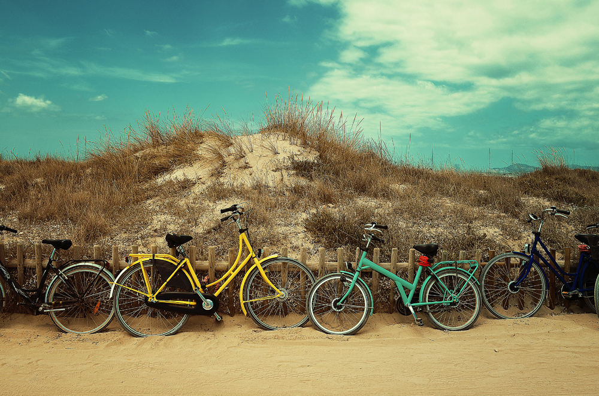

```python
#Photo by Bogdan Dada on Unsplash
from IPython import display
from PIL import Image

display.Image("bikes_1.jpg")
```

## Data Importing/ Data Preprocessing

```python
#import data/ drop not needed columns
import pandas as pd
import numpy as np
bikes = pd.read_csv('bikes.csv')
bikes=bikes.drop(columns = ['atemp','casual','registered'])
bikes
```

|  | datetime | season | holiday | workingday | weather | temp | humidity | windspeed | count |
| --- | --- | --- | --- | --- | --- | --- | --- | --- | --- |
| 0 | 2011-01-01 00:00:00 | 1 | 0 | 0 | 1 | 9.84 | 81 | 0.0000 | 16 |
| 1 | 2011-01-01 01:00:00 | 1 | 0 | 0 | 1 | 9.02 | 80 | 0.0000 | 40 |
| 2 | 2011-01-01 02:00:00 | 1 | 0 | 0 | 1 | 9.02 | 80 | 0.0000 | 32 |
| 3 | 2011-01-01 03:00:00 | 1 | 0 | 0 | 1 | 9.84 | 75 | 0.0000 | 13 |
| 4 | 2011-01-01 04:00:00 | 1 | 0 | 0 | 1 | 9.84 | 75 | 0.0000 | 1 |
| ... | ... | ... | ... | ... | ... | ... | ... | ... | ... |
| 10881 | 2012-12-19 19:00:00 | 4 | 0 | 1 | 1 | 15.58 | 50 | 26.0027 | 336 |
| 10882 | 2012-12-19 20:00:00 | 4 | 0 | 1 | 1 | 14.76 | 57 | 15.0013 | 241 |
| 10883 | 2012-12-19 21:00:00 | 4 | 0 | 1 | 1 | 13.94 | 61 | 15.0013 | 168 |
| 10884 | 2012-12-19 22:00:00 | 4 | 0 | 1 | 1 | 13.94 | 61 | 6.0032 | 129 |
| 10885 | 2012-12-19 23:00:00 | 4 | 0 | 1 | 1 | 13.12 | 66 | 8.9981 | 88 |

10886 rows × 9 columns

```python
#extract year, month, hour and drop datetime column
bikes['year']=bikes['datetime'].str.slice(3,4).astype(int)
bikes['month']=bikes['datetime'].str.slice(5,7).astype(int)
bikes['hour']=bikes['datetime'].str.slice(11,13).astype(int)
bikes = bikes.drop(columns = ['datetime'])
bikes
```

|  | season | holiday | workingday | weather | temp | humidity | windspeed | count | year | month | hour |
| --- | --- | --- | --- | --- | --- | --- | --- | --- | --- | --- | --- |
| 0 | 1 | 0 | 0 | 1 | 9.84 | 81 | 0.0000 | 16 | 1 | 1 | 0 |
| 1 | 1 | 0 | 0 | 1 | 9.02 | 80 | 0.0000 | 40 | 1 | 1 | 1 |
| 2 | 1 | 0 | 0 | 1 | 9.02 | 80 | 0.0000 | 32 | 1 | 1 | 2 |
| 3 | 1 | 0 | 0 | 1 | 9.84 | 75 | 0.0000 | 13 | 1 | 1 | 3 |
| 4 | 1 | 0 | 0 | 1 | 9.84 | 75 | 0.0000 | 1 | 1 | 1 | 4 |
| ... | ... | ... | ... | ... | ... | ... | ... | ... | ... | ... | ... |
| 10881 | 4 | 0 | 1 | 1 | 15.58 | 50 | 26.0027 | 336 | 2 | 12 | 19 |
| 10882 | 4 | 0 | 1 | 1 | 14.76 | 57 | 15.0013 | 241 | 2 | 12 | 20 |
| 10883 | 4 | 0 | 1 | 1 | 13.94 | 61 | 15.0013 | 168 | 2 | 12 | 21 |
| 10884 | 4 | 0 | 1 | 1 | 13.94 | 61 | 6.0032 | 129 | 2 | 12 | 22 |
| 10885 | 4 | 0 | 1 | 1 | 13.12 | 66 | 8.9981 | 88 | 2 | 12 | 23 |

10886 rows × 11 columns

```python
#create a copy
bikes_copy = bikes.copy()
bikes_copy
```

|  | season | holiday | workingday | weather | temp | humidity | windspeed | count | year | month | hour |
| --- | --- | --- | --- | --- | --- | --- | --- | --- | --- | --- | --- |
| 0 | 1 | 0 | 0 | 1 | 9.84 | 81 | 0.0000 | 16 | 1 | 1 | 0 |
| 1 | 1 | 0 | 0 | 1 | 9.02 | 80 | 0.0000 | 40 | 1 | 1 | 1 |
| 2 | 1 | 0 | 0 | 1 | 9.02 | 80 | 0.0000 | 32 | 1 | 1 | 2 |
| 3 | 1 | 0 | 0 | 1 | 9.84 | 75 | 0.0000 | 13 | 1 | 1 | 3 |
| 4 | 1 | 0 | 0 | 1 | 9.84 | 75 | 0.0000 | 1 | 1 | 1 | 4 |
| ... | ... | ... | ... | ... | ... | ... | ... | ... | ... | ... | ... |
| 10881 | 4 | 0 | 1 | 1 | 15.58 | 50 | 26.0027 | 336 | 2 | 12 | 19 |
| 10882 | 4 | 0 | 1 | 1 | 14.76 | 57 | 15.0013 | 241 | 2 | 12 | 20 |
| 10883 | 4 | 0 | 1 | 1 | 13.94 | 61 | 15.0013 | 168 | 2 | 12 | 21 |
| 10884 | 4 | 0 | 1 | 1 | 13.94 | 61 | 6.0032 | 129 | 2 | 12 | 22 |
| 10885 | 4 | 0 | 1 | 1 | 13.12 | 66 | 8.9981 | 88 | 2 | 12 | 23 |

10886 rows × 11 columns

```python
#get dummies from weather column, standarize temp, humidity and windspeed columns
bikes_copy = pd.get_dummies(bikes_copy, columns=['weather'], drop_first = True)
from sklearn.preprocessing import StandardScaler

col_names = ["temp", "humidity","windspeed"]
features = bikes_copy[col_names]
scaler = StandardScaler().fit(features.values)
features = scaler.transform(features.values)

bikes_copy[col_names] = features
bikes_copy
```

|  | season | holiday | workingday | temp | humidity | windspeed | count | year | month | hour | weather_2 | weather_3 | weather_4 |
| --- | --- | --- | --- | --- | --- | --- | --- | --- | --- | --- | --- | --- | --- |
| 0 | 1 | 0 | 0 | -1.333661 | 0.993213 | -1.567754 | 16 | 1 | 1 | 0 | 0 | 0 | 0 |
| 1 | 1 | 0 | 0 | -1.438907 | 0.941249 | -1.567754 | 40 | 1 | 1 | 1 | 0 | 0 | 0 |
| 2 | 1 | 0 | 0 | -1.438907 | 0.941249 | -1.567754 | 32 | 1 | 1 | 2 | 0 | 0 | 0 |
| 3 | 1 | 0 | 0 | -1.333661 | 0.681430 | -1.567754 | 13 | 1 | 1 | 3 | 0 | 0 | 0 |
| 4 | 1 | 0 | 0 | -1.333661 | 0.681430 | -1.567754 | 1 | 1 | 1 | 4 | 0 | 0 | 0 |
| ... | ... | ... | ... | ... | ... | ... | ... | ... | ... | ... | ... | ... | ... |
| 10881 | 4 | 0 | 1 | -0.596935 | -0.617666 | 1.617227 | 336 | 2 | 12 | 19 | 0 | 0 | 0 |
| 10882 | 4 | 0 | 1 | -0.702182 | -0.253919 | 0.269704 | 241 | 2 | 12 | 20 | 0 | 0 | 0 |
| 10883 | 4 | 0 | 1 | -0.807428 | -0.046064 | 0.269704 | 168 | 2 | 12 | 21 | 0 | 0 | 0 |
| 10884 | 4 | 0 | 1 | -0.807428 | -0.046064 | -0.832442 | 129 | 2 | 12 | 22 | 0 | 0 | 0 |
| 10885 | 4 | 0 | 1 | -0.912675 | 0.213755 | -0.465608 | 88 | 2 | 12 | 23 | 0 | 0 | 0 |

10886 rows × 13 columns

```python
# Create arrays for the features and the response variable
y = bikes_copy['count'].values
X = bikes_copy.drop('count', axis=1).values

#split data in train and test
from sklearn.model_selection import train_test_split
X_train, X_test, y_train, y_test = train_test_split(X, y,
test_size = 0.3, random_state=42)
```

# Fit data with several models

Below, I fit the data with several models, calculate the time it takes the models to run, calculate the RMSE for each model, plot for all models for comparison reasons. Select features with different methods. Finally, in some cases I tuned the models hyperparameters for best fitting

```python
#create a linear regression model and fit for train data
from sklearn.linear_model import LinearRegression
from sklearn.metrics import mean_squared_error as MSE
import time
start_time = time.time()
LinReg = LinearRegression()
LinReg.fit(X_train, y_train)
#predict for test data and calculate score
y_pred_LinReg = LinReg.predict(X_test)
rmse_LinReg = MSE(y_test, y_pred_LinReg)**(1/2)
end_time = time.time()
time_LinReg = end_time - start_time
print('Test set RMSE of LinReg: {:.2f}'.format(rmse_LinReg))
print("Result calculated in {:.5f} sec".format(time_LinReg))
```

```
Test set RMSE of LinReg: 141.05
Result calculated in 0.02491 sec
```

```python
#create a lasso regression model and fit for train data

from sklearn.linear_model import Lasso
start_time = time.time()
lasso = Lasso(alpha=0.1, normalize=True)
lasso.fit(X_train, y_train)
y_pred_lasso = lasso.predict(X_test)
#lasso.score(X_test, y_test)
rmse_lasso = MSE(y_test, y_pred_lasso)**(1/2)
end_time = time.time()
time_lasso = end_time - start_time
print('Test set RMSE of Lasso: {:.2f}'.format(rmse_lasso))
print("Result calculated in {:.5f} sec".format(time_lasso))
```

```
Test set RMSE of Lasso: 142.39
Result calculated in 0.01300 sec
```

```python
import matplotlib.pyplot as plt
plt.rcParams.update({'font.size': 15})
```

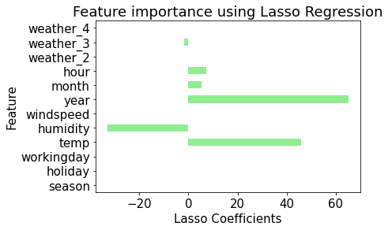

```python
# Create a pd.Series of features importances
lasso_coef = pd.Series(lasso.fit(X_train, y_train).coef_, index = bikes_copy.drop('count', axis=1).columns)
lasso_coef.plot(kind='barh', color='lightgreen')
plt.xlabel('Lasso Coefficients')
plt.ylabel('Feature')
plt.title('Feature importance using Lasso Regression')
plt.show()
```

```python
#apply also ridge regression
from sklearn.linear_model import Ridge
start_time = time.time()
ridge = Ridge(alpha=0.1, normalize=True)
ridge.fit(X_train, y_train)
y_pred_ridge = ridge.predict(X_test)
rmse_ridge = MSE(y_test, y_pred_ridge)**(1/2)
end_time = time.time()
time_ridge = end_time - start_time
print('Test set RMSE of Lasso: {:.2f}'.format(rmse_ridge))
print("Result calculated in {:.5f} sec".format(time_ridge))
```

```
Test set RMSE of Lasso: 141.36
Result calculated in 0.01400 sec
```

```python
#fit the data with a Decision Tree Regressor
# Import GridSearchCV
from sklearn.model_selection import GridSearchCV
from sklearn.tree import DecisionTreeRegressor
# Define the grid of hyperparameters 'params_dt'
params_dt = {
'max_depth': [2, 5,10],
'max_features': [0.2, 0.4,0.6, 0.8]
}

dt = DecisionTreeRegressor(random_state=42)

grid_dt = GridSearchCV(estimator=dt,
param_grid=params_dt,
cv=5)

# Fit 'grid_dt' to the training data
grid_dt.fit(X_train, y_train)

best_hyperparams = grid_dt.best_params_
print('Best hyerparameters:\n', best_hyperparams)
```

```
Best hyerparameters:
 {'max_depth': 10, 'max_features': 0.8}
```

```python
import time
start_time = time.time()
# Instantiate a DecisionTreeRegressor 'dt'
dt = DecisionTreeRegressor(max_depth=10,
max_features=0.8,
random_state=42)
# Fit 'dt' to the training-set
dt.fit(X_train, y_train)
# Predict test-set labels
y_pred_dt = dt.predict(X_test)

rmse_dt = MSE(y_test, y_pred_dt)**(1/2)
end_time = time.time()
time_dt = end_time - start_time
print('Test set RMSE of Decision Tree: {:.2f}'.format(rmse_dt))
print("Result calculated in {:.5f} sec".format(time_dt))
```

```
Test set RMSE of Decision Tree: 60.09
Result calculated in 0.01800 sec
```

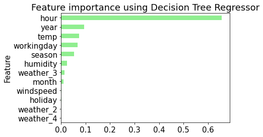

```python
# Create a pd.Series of features importances
importances_dt = pd.Series(dt.feature_importances_, index = bikes_copy.drop('count', axis=1).columns)
sorted_importances_dt = importances_dt.sort_values()
# Make a horizontal bar plot
sorted_importances_dt.plot(kind='barh', color='lightgreen')
plt.ylabel('Feature')
plt.title('Feature importance using Decision Tree Regressor')
plt.show();
```

```python
#fit the data with a Random Forest Regressor

from sklearn.ensemble import RandomForestRegressor
# Define the grid of hyperparameters 'params_dt'
params_rf = {
'max_depth': [4, 6,8],
'n_estimators': [300, 400, 500],
}

rf = RandomForestRegressor(random_state=42)

grid_rf = GridSearchCV(estimator=rf,
param_grid=params_rf,
cv=5)

# Fit 'grid_dt' to the training data
grid_rf.fit(X_train, y_train)

best_hyperparams = grid_rf.best_params_
print('Best hyerparameters:\n', best_hyperparams)
```

```
Best hyerparameters:
 {'max_depth': 8, 'n_estimators': 300}
```

```python
start_time = time.time()
rf = RandomForestRegressor(max_depth=8,
n_estimators=300,
random_state=42)
rf.fit(X_train, y_train)
# Predict test-set labels
y_pred_rf = rf.predict(X_test)

rmse_rf = MSE(y_test, y_pred_rf)**(1/2)
end_time = time.time()
time_rf = end_time - start_time
print('Test set RMSE of Random Forest Regressor: {:.2f}'.format(rmse_rf))
print("Result calculated in {:.5f} sec".format(time_rf))
```

```
Test set RMSE of Random Forest Regressor: 60.65
Result calculated in 3.17330 sec
```

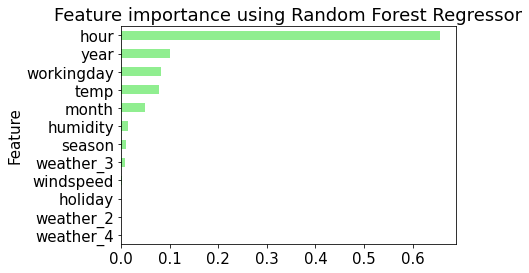

```python
# Create a pd.Series of features importances
importances_rf = pd.Series(rf.feature_importances_, index = bikes_copy.drop('count', axis=1).columns)
# Sort importances_rf
sorted_importances_rf = importances_rf.sort_values()
# Make a horizontal bar plot
sorted_importances_rf.plot(kind='barh', color='lightgreen')
plt.ylabel('Feature')
plt.title('Feature importance using Random Forest Regressor')
plt.show();
```

```python
#use selectkbest for find the best features with this method
from sklearn.feature_selection import SelectKBest
from sklearn.feature_selection import f_regression

fs = SelectKBest(score_func=f_regression, k='all')
z = fs.fit_transform(X_train, y_train)
```

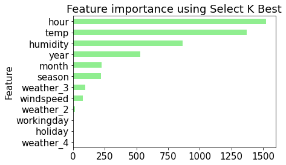

```python
# Create a pd.Series of features importances
importances_SKBest = pd.Series(fs.scores_, index = bikes_copy.drop('count', axis=1).columns)
# Sort importances_rf
sorted_importances_SKBest = importances_SKBest.sort_values()
# Make a horizontal bar plot
sorted_importances_SKBest.plot(kind='barh', color='lightgreen')
plt.ylabel('Feature')
plt.title('Feature importance using Select K Best')
plt.show();
```

```python
# Create table with summary of the above models
rmse = [rmse_LinReg, rmse_lasso, rmse_ridge, rmse_dt, rmse_rf]
model = ['LinReg', 'lasso', 'ridge', 'dt', 'rf']
time = [time_LinReg, time_lasso, time_ridge, time_dt, time_rf]

zipped = list(zip(model, rmse,time))
summary = pd.DataFrame(zipped, columns=['model', 'rmse', 'time'])
summary
```

|  | model | rmse | time |
| --- | --- | --- | --- |
| 0 | LinReg | 141.054690 | 0.024913 |
| 1 | lasso | 142.389906 | 0.013001 |
| 2 | ridge | 141.359330 | 0.014004 |
| 3 | dt | 60.088117 | 0.018000 |
| 4 | rf | 60.652950 | 3.173303 |

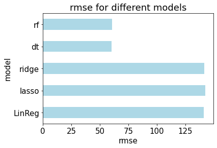

```python
rmse_plot = summary.plot.barh(x='model', y='rmse', color='lightblue', legend=None)
plt.xlabel('rmse')
plt.title('rmse for different models')
plt.show()
```

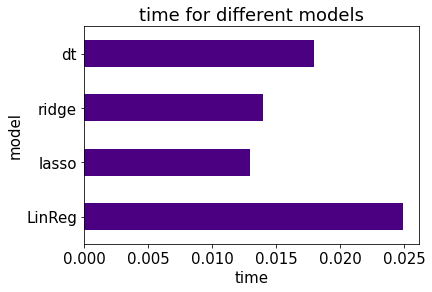

```python
summary_time = summary[summary['time']<1]

rmse_plot = summary_time.plot.barh(x='model', y='time', color='indigo', legend=None)
plt.xlabel('time')
plt.title('time for different models')
plt.show()
```

# Models with less features

Based on the several feature charts above, I reduce the model features to 5 and try to calculate again the time and the RMSE. I compared those values with the initial models with all features.

The models used are:  
**model 1** : 'hour','temp','humidity','month','year','count' (as suggested by lasso and kbest)  
**model 2** : 'hour','temp','workingday','season','year','count' (as suggested by dt)  
**model 3** : 'hour','temp','workingday','month','year','count' (as suggested by rf)

I fit the models with linear regression and dt below.

```python
model_1 = bikes_copy[['hour','temp','humidity','month','year','count']] #lasso
# Create arrays for the features and the response variable
y_model_1 = model_1['count'].values
X_model_1 = model_1.drop('count', axis=1).values

#import packages from sklearn
X_train_model_1, X_test_model_1, y_train_model_1, y_test_model_1 = train_test_split(X_model_1, y_model_1,
test_size = 0.3, random_state=42)
```

```python
import time
start_time = time.time()
LinReg_model_1 = LinearRegression()
LinReg_model_1.fit(X_train_model_1, y_train_model_1)
#predict for test data and calculate score
y_pred_LinReg_model_1 = LinReg_model_1.predict(X_test_model_1)
rmse_LinReg_model_1 = MSE(y_test_model_1, y_pred_LinReg_model_1)**(1/2)
end_time = time.time()
time_LinReg_model_1 = end_time - start_time
print('Test set RMSE of LinReg: {:.2f}'.format(rmse_LinReg_model_1))
print("Result calculated in {:.5f} sec".format(time_LinReg_model_1))
```

```
Test set RMSE of LinReg: 141.43
Result calculated in 0.00300 sec
```

```python
import time
```

```python
model_2 = bikes_copy[['hour','temp','workingday','season','year','count']]
# Create arrays for the features and the response variable
y_model_2 = model_2['count'].values
X_model_2 = model_2.drop('count', axis=1).values

#import packages from sklearn
X_train_model_2, X_test_model_2, y_train_model_2, y_test_model_2 = train_test_split(X_model_2, y_model_2,
test_size = 0.3, random_state=42)
```

```python
start_time = time.time()
LinReg_model_2 = LinearRegression()
LinReg_model_2.fit(X_train_model_2, y_train_model_2)
#predict for test data and calculate score
y_pred_LinReg_model_2 = LinReg_model_2.predict(X_test_model_2)
rmse_LinReg_model_2 = MSE(y_test_model_2, y_pred_LinReg_model_2)**(1/2)
end_time = time.time()
time_LinReg_model_2 = end_time - start_time
print('Test set RMSE of LinReg: {:.2f}'.format(rmse_LinReg_model_2))
print("Result calculated in {:.5f} sec".format(time_LinReg_model_2))
```

```
Test set RMSE of LinReg: 146.87
Result calculated in 0.00400 sec
```

```python
model_3 = bikes_copy[['hour','temp','workingday','month','year','count']]
# Create arrays for the features and the response variable
y_model_3 = model_3['count'].values
X_model_3 = model_3.drop('count', axis=1).values

#import packages from sklearn
X_train_model_3, X_test_model_3, y_train_model_3, y_test_model_3 = train_test_split(X_model_3, y_model_3,
test_size = 0.3, random_state=42)
```

```python
start_time = time.time()
LinReg_model_3 = LinearRegression()
LinReg_model_3.fit(X_train_model_3, y_train_model_3)
#predict for test data and calculate score
y_pred_LinReg_model_3 = LinReg_model_3.predict(X_test_model_3)
rmse_LinReg_model_3 = MSE(y_test_model_3, y_pred_LinReg_model_3)**(1/2)
end_time = time.time()
time_LinReg_model_3 = end_time - start_time
print('Test set RMSE of LinReg: {:.2f}'.format(rmse_LinReg_model_3))
print("Result calculated in {:.5f} sec".format(time_LinReg_model_3))
```

```
Test set RMSE of LinReg: 146.70
Result calculated in 0.00400 sec
```

```python
# Create summary table
rmse_lr = [rmse_LinReg, rmse_LinReg_model_1, rmse_LinReg_model_2, rmse_LinReg_model_3]
model_lr = ['LinReg', 'model_1', 'model_2', 'model_3']
time_lr = [time_LinReg, time_LinReg_model_1, time_LinReg_model_2, time_LinReg_model_3]

zipped_lr = list(zip(model_lr, rmse_lr,time_lr))
summary_lr = pd.DataFrame(zipped_lr, columns=['model', 'rmse', 'time'])
summary_lr
```

|  | model | rmse | time |
| --- | --- | --- | --- |
| 0 | LinReg | 141.054690 | 0.024913 |
| 1 | model_1 | 141.434368 | 0.003002 |
| 2 | model_2 | 146.868463 | 0.004003 |
| 3 | model_3 | 146.703098 | 0.004002 |

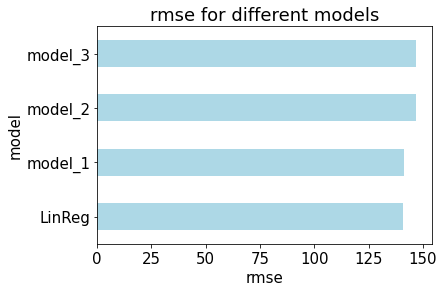

```python
rmse_plot_lr = summary_lr.plot.barh(x='model', y='rmse', color='lightblue', legend=None)
plt.xlabel('rmse')
plt.title('rmse for different models')
plt.show()
```

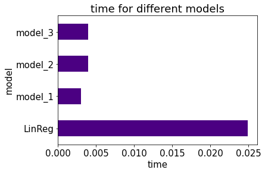

```python
rmse_plot_lr = summary_lr.plot.barh(x='model', y='time', color='indigo', legend=None)
plt.xlabel('time')
plt.title('time for different models')
plt.show()
```

```python
# Import DecisionTreeRegressor

start_time = time.time()
# Instantiate a DecisionTreeRegressor 'dt'
dt_model_1 = DecisionTreeRegressor(max_depth=10,
max_features=0.8,
random_state=42)
# Fit 'dt' to the training-set
dt_model_1.fit(X_train_model_1, y_train_model_1)
# Predict test-set labels
y_pred_dt_model_1 = dt_model_1.predict(X_test_model_1)

rmse_dt_model_1 = MSE(y_test_model_1, y_pred_dt_model_1)**(1/2)
end_time = time.time()
time_dt_model_1 = end_time - start_time
print('Test set RMSE of Decision Tree: {:.2f}'.format(rmse_dt_model_1))
print("Result calculated in {:.5f} sec".format(time_dt_model_1))
```

```
Test set RMSE of Decision Tree: 96.73
Result calculated in 0.01500 sec
```

```python
# Import DecisionTreeRegressor

start_time = time.time()
# Instantiate a DecisionTreeRegressor 'dt'
dt_model_2 = DecisionTreeRegressor(max_depth=10,
max_features=0.8,
random_state=42)
# Fit 'dt' to the training-set
dt_model_2.fit(X_train_model_2, y_train_model_2)
# Predict test-set labels
y_pred_dt_model_2 = dt_model_2.predict(X_test_model_2)

rmse_dt_model_2 = MSE(y_test_model_2, y_pred_dt_model_2)**(1/2)
end_time = time.time()
time_dt_model_2 = end_time - start_time
print('Test set RMSE of Decision Tree: {:.2f}'.format(rmse_dt_model_2))
print("Result calculated in {:.5f} sec".format(time_dt_model_2))
```

```
Test set RMSE of Decision Tree: 64.37
Result calculated in 0.01100 sec
```

```python
# Import DecisionTreeRegressor

start_time = time.time()
# Instantiate a DecisionTreeRegressor 'dt'
dt_model_3 = DecisionTreeRegressor(max_depth=10,
max_features=0.8,
random_state=42)
# Fit 'dt' to the training-set
dt_model_3.fit(X_train_model_3, y_train_model_3)
# Predict test-set labels
y_pred_dt_model_3 = dt_model_3.predict(X_test_model_3)

rmse_dt_model_3 = MSE(y_test_model_3, y_pred_dt_model_3)**(1/2)
end_time = time.time()
time_dt_model_3 = end_time - start_time
print('Test set RMSE of Decision Tree: {:.2f}'.format(rmse_dt_model_3))
print("Result calculated in {:.5f} sec".format(time_dt_model_3))
```

```
Test set RMSE of Decision Tree: 67.16
Result calculated in 0.01100 sec
```

```python
# Create summary table
rmse_dt = [rmse_dt, rmse_dt_model_1, rmse_dt_model_2, rmse_dt_model_3]
model_dt = ['dt', 'model_1', 'model_2', 'model_3']
time_dt = [time_dt, time_dt_model_1, time_dt_model_2, time_dt_model_3]

zipped_dt = list(zip(model_dt, rmse_dt,time_dt))
summary_dt = pd.DataFrame(zipped_dt, columns=['model', 'rmse', 'time'])
summary_dt
```

|  | model | rmse | time |
| --- | --- | --- | --- |
| 0 | dt | 60.088117 | 0.018000 |
| 1 | model_1 | 96.730301 | 0.015002 |
| 2 | model_2 | 64.366959 | 0.010997 |
| 3 | model_3 | 67.159753 | 0.010999 |

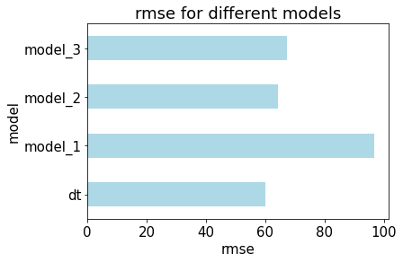

```python
rmse_plot_dt = summary_dt.plot.barh(x='model', y='rmse',  color='lightblue', legend=None)
plt.xlabel('rmse')
plt.title('rmse for different models')
plt.show()
```

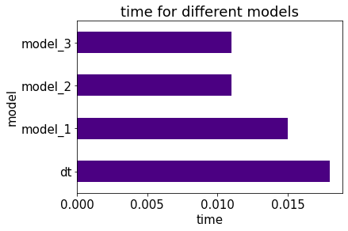

```python
rmse_plot_dt = summary_dt.plot.barh(x='model', y='time', color='indigo', legend=None)
plt.xlabel('time')
plt.title('time for different models')
plt.show()
```

Finally, we can see from the final 4 charts that the more simple models can be faster and can have similar rmse.

# Summary